# rmarkdown_1

Yinan Fneg

2023-09-26

## Load needed packages

```r
library(tidyverse)
library(sf)
library(ggspatial)
```

```r
library(ggplot2)
```

## Load the data

Load the ‘knox_acs.shp’ shapefile into R and give it the name ‘knox’.

## Add column

Add a new column to knox that calculates the fraction of each census tract that is between ages 18 and 21. Call that column “college_frac”.

## Choropleth plot

Create a choropleth map of the proportion of the population age 18-21. Make sure that the map is appropriately labeled.

[output not shown]

```
## Zoom: 9
```

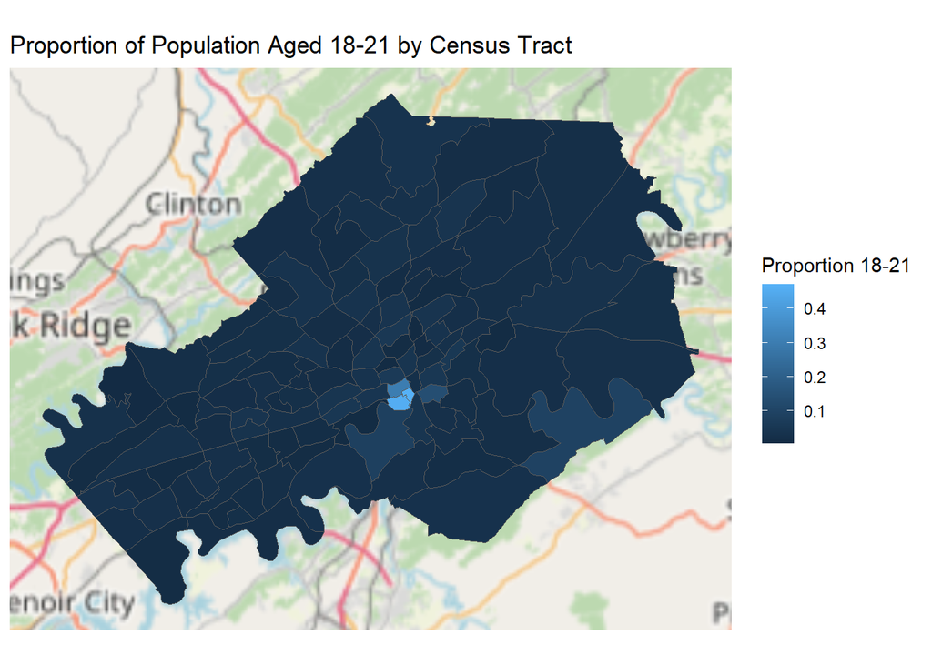

## Histogram plot

Plot a histogram of the Median Household Income and label the axes appropriately. In words, describe the shape of this distribution.

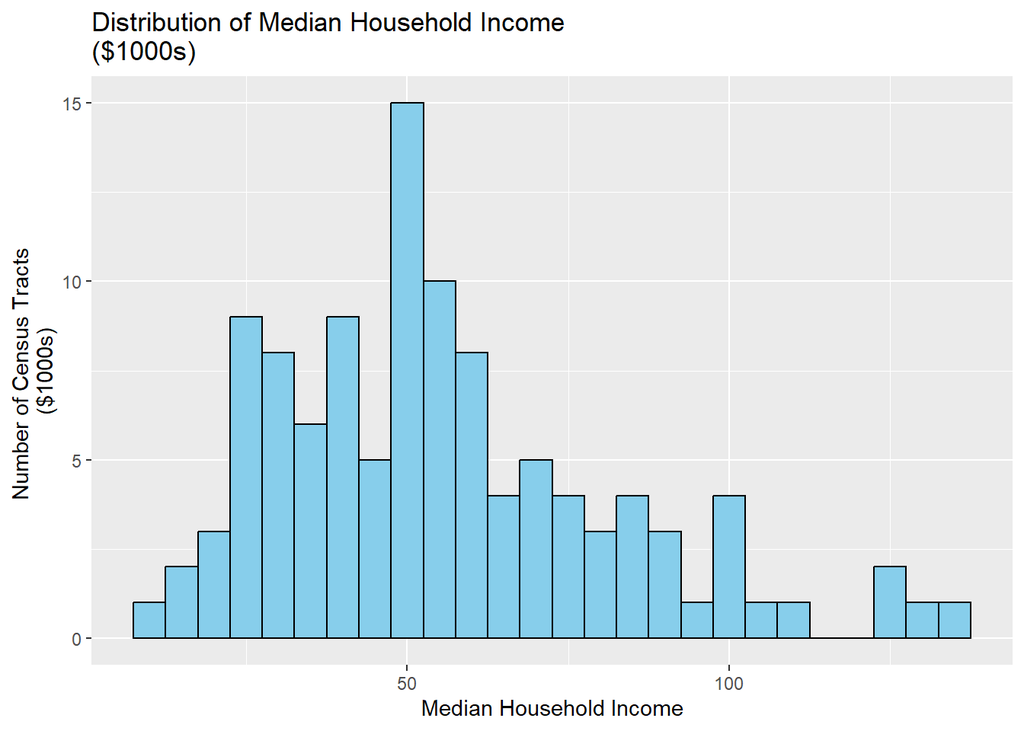

Create a scatterplot with Household Income (in $1000s) on the x-axis and House Value (in $1000s) on the y-axis. Set the alpha level to the population of each tract. Describe in words the shape of this scatterplot.

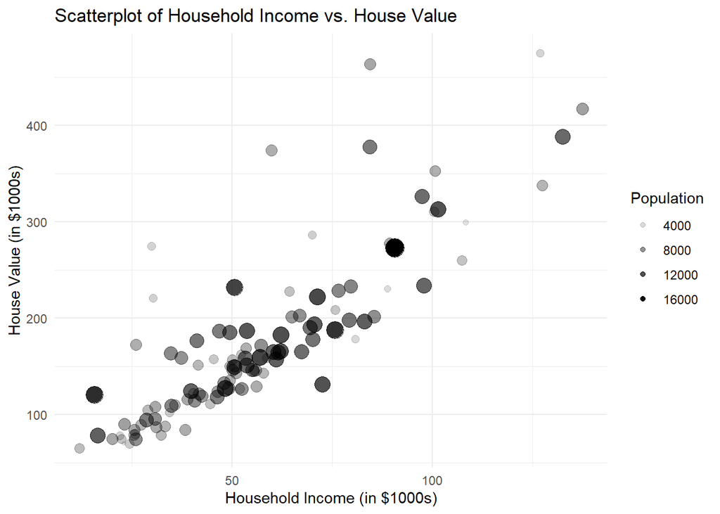

## Correlation

Calculate the three correlation coefficients between Household Income, House Value, and percent 18-21. Use these correlation coefficients in a sentence without typing the numbers in directly. (i.e. your markdown file should generate the coefficient automatically for you).

The correlation coefficient between Household Income (`MEDHHINC`) and House Value (`MEDHVALUE`) is 0.84. The correlation coefficient between Household Income (`MEDHHINC`) and the percentage of the population aged 18-21 (`college_frac`) is -0.31. Lastly, the correlation coefficient between House Value (`MEDHVALUE`) and the percentage of the population aged 18-21 (`college_frac`) is -0.2.